# Session 4 - Numerische Analyse

22. Mai 2018

## Syllabus

Session 1 - R and RStudio

Session 2 - Data Typen und erste Befehle

Session 3 - Daten einlesen und speichern

`Session 4 - Einfache Analyse (numerisch)`

Session 5 - Visualisierung

Session 6 - Application Programming Interfaces (APIs)

Session 7 - Introduction to Text Mining

Session 8 & 9 - Web Scraping

## Agenda

1. Hausaufgaben besprechen
2. Dokumentation
3. Subsetting
4. Aufgaben
5. Einfache Analysen
6. Aufgaben

## 1. Hausaufgaben besprechen

## Aufgaben

1. Inspiziere die unterschiedlichen Dateien des Ordners `./Data/Session_3`.
2. Lade alle Dateien in R und speicher sie in unterschiedlichen, aussagekräftigen Variablen.
3. Schaue dir die Variablen mit Hilfe des Befehls `View()` an.
4. Füge die vier Teildatensätze sinnvoll zusammen. Überlege sorgfältig, welche der kennengelernten Funktionen du dabei benötigst und welche nicht.
5. Speicher den finalen Datensatz im rds-Format in deinem Projektordner unter `/data/gtdb.RDS`.

## Probleme mit Trennzeichen

- `read_csv` für Daten die mit Komma `,` getrennt sind.
- `read_csv2` für Daten die mit Semikolon `;` getrennt sind.
- `read_tsv` für Daten die mit Tab `\t` getrennt sind.
- Allgemein kann man `read_delim` benutzten und alle Parameter selber spezifizieren. Die vorherigen Funktionen sind Spezialfälle von `read_delim`.

## gtdb_1998-2014.xlsx

```r
gtdb_1998_2014 <- read_excel("./Data/Session_3/gtdb_1998-2014.xlsx")
head(gtdb_1998_2014)
```

```
## # A tibble: 6 x 19
##   eventid iyear imonth  iday specificity summary crit1 crit2 crit3 success
##     <dbl> <dbl>  <dbl> <dbl>       <dbl> <chr>   <dbl> <dbl> <dbl>   <dbl>
## 1 2.00e11 1998.     1.    1.          1. 01/01/…    1.    1.    1.      1.
## 2 2.00e11 1998.     1.    1.          1. 01/01/…    1.    1.    1.      1.
## 3 2.00e11 1998.     1.    1.          1. 01/01/…    1.    1.    1.      1.
## 4 2.00e11 1998.     1.    2.          1. 01/02/…    1.    1.    1.      1.
## 5 2.00e11 1998.     1.    2.          4. 01/02/…    1.    1.    1.      0.
## 6 2.00e11 1998.     1.    4.          1. 01/04/…    1.    1.    1.      1.
## # ... with 9 more variables: suicide <dbl>, attacktype1 <dbl>,
## #   attacktype1_txt <chr>, targtype1 <dbl>, targtype1_txt <chr>,
## #   natlty1 <dbl>, natlty1_txt <chr>, gname <chr>, nkill <dbl>
```

## gtdb_2015.tsv

```r
gtdb_2015 <- read_tsv("./Data/Session_3/gtdb_2015.tsv")
head(gtdb_2015)
```

```
## # A tibble: 6 x 19
##   eventid iyear imonth  iday specificity summary crit1 crit2 crit3 success
##     <dbl> <int>  <int> <int>       <int> <chr>   <int> <int> <int>   <int>
## 1 2.01e11  2015      1     3           1 01/03/…     1     1     1       1
## 2 2.01e11  2015      1     1           1 01/01/…     1     1     1       1
## 3 2.02e11  2015      1     1           1 01/01/…     1     1     1       1
## 4 2.02e11  2015      1     1           1 01/01/…     1     1     1       0
## 5 2.02e11  2015      1     1           1 01/01/…     1     1     1       1
## 6 2.02e11  2015      1     1           1 01/01/…     1     1     1       1
## # ... with 9 more variables: suicide <int>, attacktype1 <int>,
## #   attacktype1_txt <chr>, targtype1 <int>, targtype1_txt <chr>,
## #   natlty1 <int>, natlty1_txt <chr>, gname <chr>, nkill <int>
```

## gtdb_2016.csv

```r
gtdb_2016 <- read_csv2("./Data/Session_3/gtdb_2016.csv")
head(gtdb_2016)
```

```
## # A tibble: 6 x 19
##   `201601010003` `2016`   `1` `1_1` `1_2` `01/01/2016: An exp… `1_3` `1_4`
##            <dbl>  <int> <int> <int> <int> <chr>                <int> <int>
## 1  201601010004.   2016     1     1     1 01/01/2016: An expl…     1     1
## 2  201601010005.   2016     1     1     1 01/01/2016: An expl…     1     1
## 3  201601010008.   2016     1     1     1 01/01/2016: Assaila…     1     1
## 4  201601010009.   2016     1     1     1 01/01/2016: Assaila…     1     1
## 5  201601010010.   2016     1     1     1 01/01/2016: A suici…     1     1
## 6  201601010011.   2016     1     1     3 01/01/2016: Assaila…     1     1
## # ... with 11 more variables: `1_5` <int>, `1_6` <int>, `0` <int>,
## #   `3` <int>, `Bombing/Explosion` <chr>, `14` <int>, `Private Citizens &
## #   Property` <chr>, `95` <int>, Iraq <chr>, Unknown <chr>, `1_7` <int>
```

## gtdb_coordinates.RData

```r
load("./Data/Session_3/gtdb_coordinates.RData")
head(gtdb_coordinates)
```

```
## # A tibble: 6 x 3
##         eventid latitude longitude
##           <dbl>    <dbl>     <dbl>
## 1 201505170064.    -42.9      147.
## 2 200112000001.    -41.3      175.
## 3 200302210006.    -41.3      175.
## 4 200303280008.    -41.3      175.
## 5 200804150015.    -41.3      175.
## 6 200806240014.    -41.3      175.
```

## Obacht: Spaltennamen (1)

- Zusätzlich muss man auf die Spaltennamen achten. Man kann eigene Spaltennamen mit dem Argument `col_names` angeben.

```r
# Spaltennamen auslesen aus gtdb_2015
headers <- names(gtdb_2015)
```

[output not shown]

## Obacht: Spaltennamen (2)

```r
# Datensatz einlesen und neue Spaltennamen übergeben
gtdb_2016 <- read_csv2("./Data/Session_3/gtdb_2016.csv",
                       col_names = headers)
```

[output not shown]

## Merge

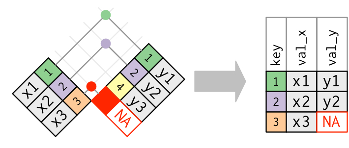

## Aufgabe 4:

```r
# Datensätze zusammenführen
gtdb <- rbind(gtdb_1998_2014,
              gtdb_2015,
              gtdb_2016)

# Koordinaten anfügen
gtdb <- merge(gtdb, gtdb_coordinates,
              by = "eventid")
```

## Aufgabe 5:

```r
# Finalen Datensatz unter './Data/' speichern
saveRDS("./Data/gtdb.RDS")
```

## 2. Dokumentation

## 3. Subsetting

## Subsetting (1)

```r
a <-  c(1, 2, 3, 4, 5, 6, 7, 8, 9, 10)
a[1:3]
```

```
## [1] 1 2 3
```

```r
b <- c(1, 2, 3, 1, 3, 5, 7, 1, 3, 1)
b[b == 1]
```

```
## [1] 1 1 1 1
```

```r
a[b >= 3]
```

```
## [1] 3 5 6 7 9
```

## Subsetting (2)

```r
s_l_f
```

```
##       Stadt      Land Fluss Einwohner
## 1  Konstanz Kolumbien Kongo        82
## 2 Stuttgart   Schweiz Seine        32
## 3     Essen   Estland  Elbe        56
```

- mit eckigen Klammern können wir uns Werte an einer bestimmten Stelle ausgaben lassen

```r
# df[row, column]
s_l_f[1, 2]
```

```
## [1] "Kolumbien"
```

## Subsetting (3)

- wenn wir den `row`-Parameter frei lassen, kriegen wir alle Reihen

```r
# df[ , column]
s_l_f[ , 2]
```

```
## [1] "Kolumbien" "Schweiz"   "Estland"
```

- wenn wir den `column`-Parameter frei lassen, kriegen wir alle Spalten

```r
# df[row, ]
s_l_f[1, ]
```

```
##      Stadt      Land Fluss Einwohner
## 1 Konstanz Kolumbien Kongo        82
```

## Subsetting (4)

- Bedingung immer nur auf der Reihe, **nie** auf der Spalte

```r
# df[Bedingung, ]
s_l_f[s_l_f$Einwohner > 50, ]
```

```
##      Stadt      Land Fluss Einwohner
## 1 Konstanz Kolumbien Kongo        82
## 3    Essen   Estland  Elbe        56
```

```r
# df[Bedingung, column]
s_l_f[s_l_f$Einwohner > 60, c("Land", "Fluss")]
```

```
##        Land Fluss
## 1 Kolumbien Kongo
```

## Subsetting (5)

```r
# df[mehrere Bedingung, ]
s_l_f[s_l_f$Einwohner == 82 | s_l_f$Land == "Schweiz", ]
```

```
##       Stadt      Land Fluss Einwohner
## 1  Konstanz Kolumbien Kongo        82
## 2 Stuttgart   Schweiz Seine        32
```

```r
# df[mehrere Bedingung, ]
s_l_f[s_l_f$Einwohner == 82 & s_l_f$Land == "Schweiz", ]
```

```
## [1] Stadt     Land      Fluss     Einwohner
## <0 rows> (or 0-length row.names)
```

## 4. Aufgaben

## Aufgaben:

Lade den Datensatz `gtdb`, den du in den Hausaufgaben erstellt hast.

1. Speicher alle Daten aus dem Jahr 2002 in einer neuen Variablen `gtdb_2002`.
2. Speicher alle Events, bei denen es mehr als 200 Tote gab in `gtdb_200`.
3. Speicher alle Summaries für Selbstmordanschläge in `summary_suicide`.
4. Speicher `Latitude`, `Longitude` und `attacktype_1_txt` für die Jahre `1999` und `2003` in `gtdb_geo`.
5. Speicher alle Daten für alle Jahre vor `2006` bei denen das Ziel das Militär war in `gtdb_military`.

## 5. Einfache Analysen

## Wichtige Befehle

### Allgemein

- `is.na`

### Kategorial

- `table`

### Numerisch

- `summary`
- `sum`, `mean`, `median`, `min`, `max`

## 6. Aufgaben

## Aufgaben (1)

1. Was ist der Median von `nkill`?
2. Wieviele Selbstmordanschläge gab es?
3. Wieviele verschiedene Kategorien hat die Variable `attacktype1_txt`?
4. Wieviele Selbstmordanschläge gab es im Jahr 2003?
5. Wie oft wurde das russische Militär angegriffen?

## Aufgaben (2)

1. Wie oft war ein Selbstmordanschlag mit einer Bombe erfolgreich?
2. Bestimme alle Kennzahlen von `nkill` und interpretiere diese.
3. Wie hoch ist der `mean` bei Selbstmordanschläge? Wie hoch bei allen anderen Fällen?
4. Wieviel Anschläge gab es im Jahr 2009 bei dem das Ziel eine `Educational Institution` oder das angegriffene Ziel aus `East Timor` war?
5. Wie oft könnte die Opferzahl nicht ermittelt werden?